# IMDB dplyr Data Munging Exercise

Robert Chang

November 15, 2014

In pursuing IMBD project using the Python:R:d3.js stack, this section is devoted to practicing **dplyr** in R. I recently encountered a very helpful [dplyr documentation](http://rstudio-pubs-static.s3.amazonaws.com/11068_8bc42d6df61341b2bed45e9a9a3bf9f4.html), but never gotten a chance to play with it. The goal of this Rmarkdown document is learn by doing. Hopefully, by the end of the this document, there is no more ugly referencing like `df[df$col1 = ]$col2` in my R code.

### STEP 1: Load Data

Let’s load dplyr first. The two dataset that we will be playing with are named `movie_data_basic.csv` and `movie_data_more.csv`.

**Pro Tip**: We can `ls` our current working directory by either `dir()` or `list.files()`. `dir()` is arguably less verbose.

```r
setwd("~/Desktop/imdb_project/")
library(dplyr)
#list.files()
dir()
```

```
##  [1] "bin"                  "imbd_dplyr.html"      "imbd_dplyr.Rmd"
##  [4] "imdb_scraper.py"      "include"              "lib"
##  [7] "movie_data_basic.csv" "movie_data_more.csv"  "movie_data.csv"
## [10] "README.md"            "share"
```

Ok, let’s now load the data using the usual read.csv functiion (I didn’t use read.table because read.csv usually works better with specific delimiters).

```r
df.basic = read.csv(file = "movie_data_basic.csv", sep = ",", header = FALSE)
colnames(df.basic) = c("name", "year", "genre", "runtime", "rating", "num_votes")
head(df.basic, 5)
```

```
##                       name year  genre runtime rating num_votes
## 1 The Shawshank Redemption 1994  Crime     142    9.3   1313944
## 2          The Dark Knight 2008 Action     152    9.0   1280745
## 3                Inception 2010 Action     148    8.8   1069844
## 4             Pulp Fiction 1994  Crime     154    9.0   1013323
## 5               Fight Club 1999  Drama     139    8.9   1009129
```

```r
df.more = read.csv(file = "movie_data_more.csv", sep = ",", header = FALSE)
colnames(df.more) = c("name", "revenue", "director", "actor1", "actor2", "actor3", "rated")
head(df.more, 5)
```

```
##                                        name  revenue          director
## 1                                    Avatar 7.61e+08     James Cameron
## 2                                   Titanic 6.59e+08     James Cameron
## 3                              The Avengers 6.23e+08       Joss Whedon
## 4                           The Dark Knight 5.33e+08 Christopher Nolan
## 5 Star Wars: Episode I - The Phantom Menace 4.75e+08      George Lucas
##              actor1       actor2             actor3 rated
## 1   Sam Worthington  Zoe Saldana   Sigourney Weaver PG_13
## 2 Leonardo DiCaprio Kate Winslet         Billy Zane PG_13
## 3 Robert Downey Jr.  Chris Evans Scarlett Johansson PG_13
## 4    Christian Bale Heath Ledger      Aaron Eckhart PG_13
## 5     Ewan McGregor  Liam Neeson    Natalie Portman    PG
```

### STEP 2: Data Join

The reason that I have two separate dataset is because I wasn’t able to find a page that contains ratings & revenue in the same url, and I had to scrape the data twice via two different ulrs. This demonstrates real world data munging, or my lack of python data scraping for that matter. Anyway, we can see that we will probably use the `name` column as the unique identifier for each row. According to [Hadley’s github page](https://github.com/hadley/dplyr), different joins have been implemented in `dplyr`. In our case, let us just inner join df.basic and df.more using name, and here is the result:

```r
df.basic$name = tolower(df.basic$name)
df.more$name = tolower(df.more$name)
df.joined = inner_join(df.basic, df.more, by = 'name')
dim(df.joined)
```

```
## [1] 3373   12
```

```r
head(df.joined)
```

```
##                                                name year     genre runtime
## 1                          the shawshank redemption 1994     Crime     142
## 2                                   the dark knight 2008    Action     152
## 3                                         inception 2010    Action     148
## 4                                      pulp fiction 1994     Crime     154
## 5                                        fight club 1999     Drama     139
## 6 the lord of the rings: the fellowship of the ring 2001 Adventure     178
##   rating num_votes  revenue          director            actor1
## 1    9.3   1313944 2.83e+07    Frank Darabont       Tim Robbins
## 2    9.0   1280745 5.33e+08 Christopher Nolan    Christian Bale
## 3    8.8   1069844 2.93e+08 Christopher Nolan Leonardo DiCaprio
## 4    9.0   1013323 1.08e+08 Quentin Tarantino     John Travolta
## 5    8.9   1009129 3.70e+07     David Fincher         Brad Pitt
## 6    8.8    961053 3.14e+08     Peter Jackson       Elijah Wood
##                 actor2               actor3 rated
## 1       Morgan Freeman           Bob Gunton     R
## 2         Heath Ledger        Aaron Eckhart PG_13
## 3 Joseph Gordon-Levitt           Ellen Page PG_13
## 4          Uma Thurman    Samuel L. Jackson     R
## 5        Edward Norton Helena Bonham Carter     R
## 6         Ian McKellen        Orlando Bloom PG_13
```

**Pro Tip**: For consistency, notice that we lower the movie names before we do the join, and in the join statement, we use the `by` argument to specify the join key.

From `dim`, we see that there are 3373 records in the joined dataset. Here is a point worth mentioning – we actually grabbed the original datasets by two URL requests: one sorted by number of votes, and one by revenue. Although there might be a lot of good questions we can ask, the implicit sorting of the movies (due to scraping) might inadvertently biased our analysis.

For example, our analysis might biased toward those that have large revenues and high votes, so any observations based on averaging might be biased toward more popular movies.

#### This thing call tbl_df

**Pro Tip**: dplyr can work with data frames as is, but if you’re dealing with large data, it’s worthwhile to convert them to a tbl_df: this is a wrapper around a data frame that won’t accidentally print a lot of data to the screen. Here is an illustration:

```r
df = tbl_df(df.joined)
df
```

```
## Source: local data frame [3,373 x 12]
##
##                                                 name year     genre
## 1                           the shawshank redemption 1994     Crime
## 2                                    the dark knight 2008    Action
## 3                                          inception 2010    Action
## 4                                       pulp fiction 1994     Crime
## 5                                         fight club 1999     Drama
## 6  the lord of the rings: the fellowship of the ring 2001 Adventure
## 7      the lord of the rings: the return of the king 2003 Adventure
## 8                                         the matrix 1999    Action
## 9                                       forrest gump 1994     Drama
## 10                                     the godfather 1972     Crime
## ..                                               ...  ...       ...
## Variables not shown: runtime (int), rating (dbl), num_votes (int), revenue
##   (dbl), director (fctr), actor1 (fctr), actor2 (fctr), actor3 (fctr),
##   rated (fctr)
```

```r
# another way to look at it
df %>% glimpse()
```

```
## Variables:
## $ name      (chr) "the shawshank redemption", "the dark knight", "ince...
## $ year      (int) 1994, 2008, 2010, 1994, 1999, 2001, 2003, 1999, 1994...
## $ genre     (fctr) Crime, Action, Action, Crime, Drama, Adventure, Adv...
## $ runtime   (int) 142, 152, 148, 154, 139, 178, 201, 136, 142, 175, 16...
## $ rating    (dbl) 9.3, 9.0, 8.8, 9.0, 8.9, 8.8, 8.9, 8.7, 8.8, 9.2, 8....
## $ num_votes (int) 1313944, 1280745, 1069844, 1013323, 1009129, 961053,...
## $ revenue   (dbl) 2.83e+07, 5.33e+08, 2.93e+08, 1.08e+08, 3.70e+07, 3....
## $ director  (fctr) Frank Darabont, Christopher Nolan, Christopher Nola...
## $ actor1    (fctr) Tim Robbins, Christian Bale, Leonardo DiCaprio, Joh...
## $ actor2    (fctr) Morgan Freeman, Heath Ledger, Joseph Gordon-Levitt,...
## $ actor3    (fctr) Bob Gunton, Aaron Eckhart, Ellen Page, Samuel L. Ja...
## $ rated     (fctr) R, PG_13, PG_13, R, R, PG_13, PG_13, R, PG_13, R, P...
```

It has some advantages and disadvantages. It will reformat the df nicely and it shows you basic information on the type of each column. However, it might choose to hide some of the columns for formatting purposes.

**Pro Tip**: `glimpse()` makes it possible to see all the columns in a tbl, displaying as much data for each variable as can be fit on a single line.

### STEP 3: Basic Exploratory Analysis

There are several interesting questions that we can ask by examining df.joined. For example:

- Is there a particular genre that tends to get higher ratings, votes, or revenue?
- Is there a particular year where movies are doing great in terms of revenue?
- Is there a particular director or movie star that tend to have great hits?

Let’s answer each question one by one, and from this exercise, we will learn how to use all the fun tools in `dplyr`, such as `filter`, `arrange`, `select`, `mutate`, `summarise`, `group_by`, `%>%` operation …etc.

#### Is there a particular genre that is super popular?

Before we answer this question, let’s just count how many movies each genre has as a warmup exercise. If I am using `plyr`, I would typically type:

```r
df.by.genre = ddply(df, .(genre), summarise, cnt = length(genre))
df.by.genre = df.by.genre[order(df.by.genre$cnt),]
df.by.genre
```

*Note: use `{r, eval = FALSE}` if you do not want to evaluate the block. The side effect is that there will be no output since we didn’t execute any code blocks.

This is too verbose, and I think we can do much better with `dplyr`:

```r
df_grp = group_by(df, genre)
df_stats = summarise(df_grp, cnt = n())
df_ordered_stats = arrange(df_stats, desc(cnt))
```

**Pro Tip**: This is slightly better than `ddply`, since each logical operation is in its own line. However, it’s still a bit too verbose, and we can further simply this code by using the `%>%` (pronouced pipe) symbol:

```r
df %>% group_by(genre) %>% summarise(cnt = n()) %>% arrange(desc(cnt))
```

```
## Source: local data frame [15 x 2]
##
##        genre cnt
## 1     Comedy 926
## 2     Action 910
## 3      Drama 510
## 4     Horror 226
## 5  Adventure 212
## 6      Crime 209
## 7  Animation 178
## 8  Biography 133
## 9    Mystery  29
## 10   Fantasy  11
## 11    Sci-Fi  10
## 12  Thriller   6
## 13    Family   5
## 14   Romance   4
## 15   Western   4
```

This is our first clean `dplyr` statement – look how succinct it is! I hope you can appreciate how chaining/piping made this series of data manipulation a lot more clearer. Looking at the list, it seems Comedy, Action, and Drama are the top 3 prolific genres.

Ok, back to our original question, is there a particular genre that is super popular? Let’s answer this question by three specific ranking metrics – we will rank the genres by average ratings, average revnue, and finally average number of votes.

```r
# By revenue
df %>%
   group_by(genre) %>%
   summarise(cnt = n(),
                 avg_rating = mean(rating),
                 avg_revenue = mean(revenue),
                 avg_votes = mean(num_votes)) %>%
  arrange(desc(avg_revenue)) %>%
  head(5)
```

```
## Source: local data frame [5 x 5]
##
##       genre cnt avg_rating avg_revenue avg_votes
## 1    Sci-Fi  10      6.560   113220000    155545
## 2 Animation 178      6.797   112381292     97732
## 3 Adventure 212      6.505    81473538    110533
## 4   Western   4      7.800    79400000    233826
## 5    Action 910      6.289    74580242    111739
```

```r
# By average rating
df %>%
   group_by(genre) %>%
   summarise(cnt = n(),
                 avg_rating = mean(rating),
                 avg_revenue = mean(revenue),
                 avg_votes = mean(num_votes)) %>%
  arrange(desc(avg_rating))
```

```
## Source: local data frame [15 x 5]
##
##        genre cnt avg_rating avg_revenue avg_votes
## 1    Western   4      7.800    79400000    233826
## 2  Biography 133      7.292    45834361     88752
## 3    Mystery  29      7.076    54253103    164010
## 4      Crime 209      6.961    41114545    115660
## 5      Drama 510      6.920    46450373     84095
## 6  Animation 178      6.797   112381292     97732
## 7   Thriller   6      6.650    20788333     40000
## 8     Sci-Fi  10      6.560   113220000    155545
## 9  Adventure 212      6.505    81473538    110533
## 10    Action 910      6.289    74580242    111739
## 11    Comedy 926      6.264    48622009     60392
## 12    Horror 226      5.937    38323274     60004
## 13   Fantasy  11      5.882    42636364     62637
## 14    Family   5      5.620    21220000     16455
## 15   Romance   4      5.525    20125000     15112
```

```r
# By average votes
df %>%
   group_by(genre) %>%
   summarise(cnt = n(),
                 avg_rating = mean(rating),
                 avg_revenue = mean(revenue),
                 avg_votes = mean(num_votes)) %>%
  arrange(desc(avg_votes))
```

```
## Source: local data frame [15 x 5]
##
##        genre cnt avg_rating avg_revenue avg_votes
## 1    Western   4      7.800    79400000    233826
## 2    Mystery  29      7.076    54253103    164010
## 3     Sci-Fi  10      6.560   113220000    155545
## 4      Crime 209      6.961    41114545    115660
## 5     Action 910      6.289    74580242    111739
## 6  Adventure 212      6.505    81473538    110533
## 7  Animation 178      6.797   112381292     97732
## 8  Biography 133      7.292    45834361     88752
## 9      Drama 510      6.920    46450373     84095
## 10   Fantasy  11      5.882    42636364     62637
## 11    Comedy 926      6.264    48622009     60392
## 12    Horror 226      5.937    38323274     60004
## 13  Thriller   6      6.650    20788333     40000
## 14    Family   5      5.620    21220000     16455
## 15   Romance   4      5.525    20125000     15112
```

*Pro Tip*: Sometimes to improve code readability, we would break up the chained commands into separate line, one for each logical operation. In these cases, make sure to put the pipe in the end of each intermediate line, so R knows that it needs to continue the evaluation for that code block.

Back to the analysis, it seems like `Sci-Fi` category get the most revenue. In terms of votes and ratings, the highest avg vote/rating genre is `Western`, but notice we only have 4 movies in that category, so this is probably more noise than an actual signal. I am curious which those 4 movies are, so let’s look them up with `filter`:

```r
df %>% filter(genre == 'Western')
```

```
## Source: local data frame [4 x 12]
##
##                   name year   genre runtime rating num_votes  revenue
## 1     django unchained 2012 Western     165    8.5    666734 1.63e+08
## 2           unforgiven 1992 Western     131    8.3    223481 1.01e+08
## 3           pale rider 1985 Western     115    7.3     32744 4.14e+07
## 4 how the west was won 1962 Western     164    7.1     12346 1.22e+07
## Variables not shown: director (fctr), actor1 (fctr), actor2 (fctr), actor3
##   (fctr), rated (fctr)
```

Wow, Clint Eastwood must be happy that his movies are there! Also, most of the Western movies are relatively old, except django unchained (2012). To improve the analysis, let’s get rid of genres that have a small sample size issue (< 100 records):

```r
# By ratings
df %>%
   group_by(genre) %>%
   summarise(cnt = n(),
                 avg_rating = mean(rating),
                 avg_revenue = mean(revenue),
                 avg_votes = mean(num_votes)) %>%
  filter(cnt >= 100) %>%
  arrange(desc(avg_rating))
```

```
## Source: local data frame [8 x 5]
##
##       genre cnt avg_rating avg_revenue avg_votes
## 1 Biography 133      7.292    45834361     88752
## 2     Crime 209      6.961    41114545    115660
## 3     Drama 510      6.920    46450373     84095
## 4 Animation 178      6.797   112381292     97732
## 5 Adventure 212      6.505    81473538    110533
## 6    Action 910      6.289    74580242    111739
## 7    Comedy 926      6.264    48622009     60392
## 8    Horror 226      5.937    38323274     60004
```

```r
# By votes
df %>%
   group_by(genre) %>%
   summarise(cnt = n(),
                 avg_rating = mean(rating),
                 avg_revenue = mean(revenue),
                 avg_votes = mean(num_votes)) %>%
  filter(cnt >= 100) %>%
  arrange(desc(avg_votes))
```

```
## Source: local data frame [8 x 5]
##
##       genre cnt avg_rating avg_revenue avg_votes
## 1     Crime 209      6.961    41114545    115660
## 2    Action 910      6.289    74580242    111739
## 3 Adventure 212      6.505    81473538    110533
## 4 Animation 178      6.797   112381292     97732
## 5 Biography 133      7.292    45834361     88752
## 6     Drama 510      6.920    46450373     84095
## 7    Comedy 926      6.264    48622009     60392
## 8    Horror 226      5.937    38323274     60004
```

With the new analysis, we see that Biography genre has the highest average rating, and Crime has the highest average votes. Cool, we’ve made some progress here, let’s move on to the next question.

#### Is there a particular year in which the movie industry is making a lot of revenue? What is the over trend over time?

Is the movie indsutry making more money over the years, you might ask? Let’s take a look:

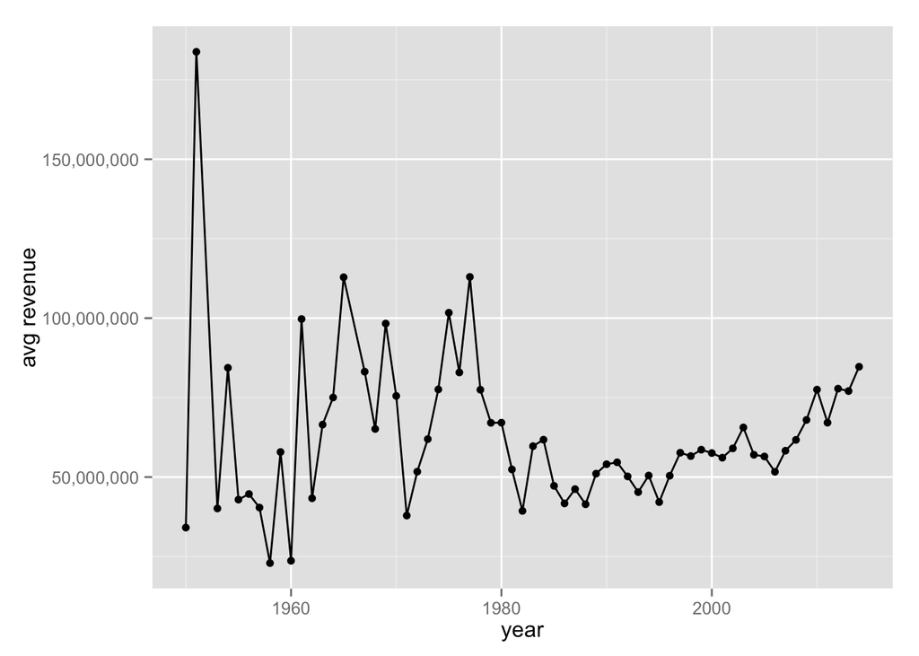

```r
df.by.year = df %>%
   select(year, revenue) %>%
   group_by(year) %>%
   summarise(cnt = n(), avg_revenue = mean(revenue)) %>%
   arrange(desc(year))

library(ggplot2)
library(scales)
ggplot(df.by.year, aes(x = year, y = avg_revenue)) + geom_point() + geom_line() + xlab("year") + ylab("avg revenue") + scale_y_continuous(labels = comma)
```

**Pro Tip**: For ggplot2, I love `library(scales)` for formatting the axes. To learn more, you can check out this [man page](http://docs.ggplot2.org/current/scale_continuous.html).

Coming back to the analysis, it seems the revenue flunctuates a lot, maybe because we didn’t have enough data points for earlier decades? We can easily check this by

```r
df.by.year %>% tail(10)
```

```
## Source: local data frame [10 x 3]
##
##    year cnt avg_revenue
## 1  1960   8    23653750
## 2  1959   5    57880000
## 3  1958   2    22925000
## 4  1957   2    40400000
## 5  1956   3    44666667
## 6  1955   4    42900000
## 7  1954   5    84380000
## 8  1953   5    40120000
## 9  1951   3   183800000
## 10 1950   1    34100000
```

and we can confirm that this claim is true. Alternatively, we can just plot year with cnt in df.by.year.

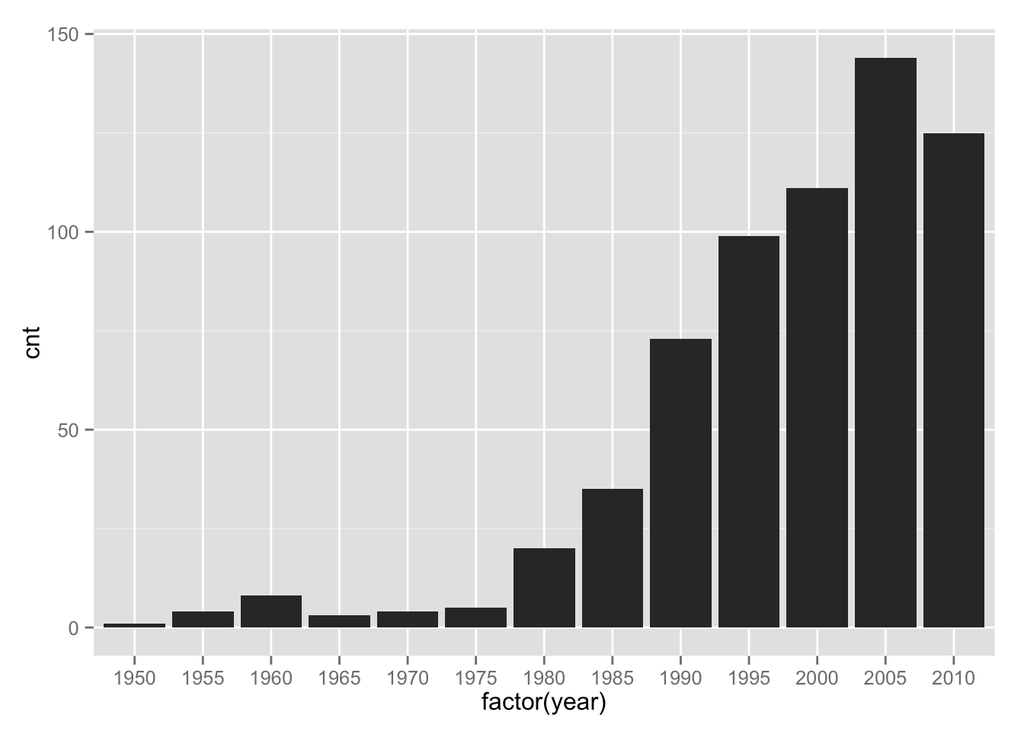

```r
df.by.year.gap = df.by.year %>% filter(year %% 5 == 0)
ggplot(df.by.year.gap, aes(x = factor(year), y = cnt)) + geom_bar(stat = "identity")
```

I only looked at the trend for cnt for every 5 years, otherwise the plot is not readable. With this visualization, it does seem like before 1990, the number of movies in our dataset is a lot smaller. So it’s best if we focus on trend post-1990s.

```r
ggplot(df.by.year %>% filter(year >= 1990), aes(x = year, y = avg_revenue)) + geom_point() + geom_line() + xlab("year") + ylab("avg revenue") + scale_y_continuous(labels = comma)
```

Equivalently, we can write:

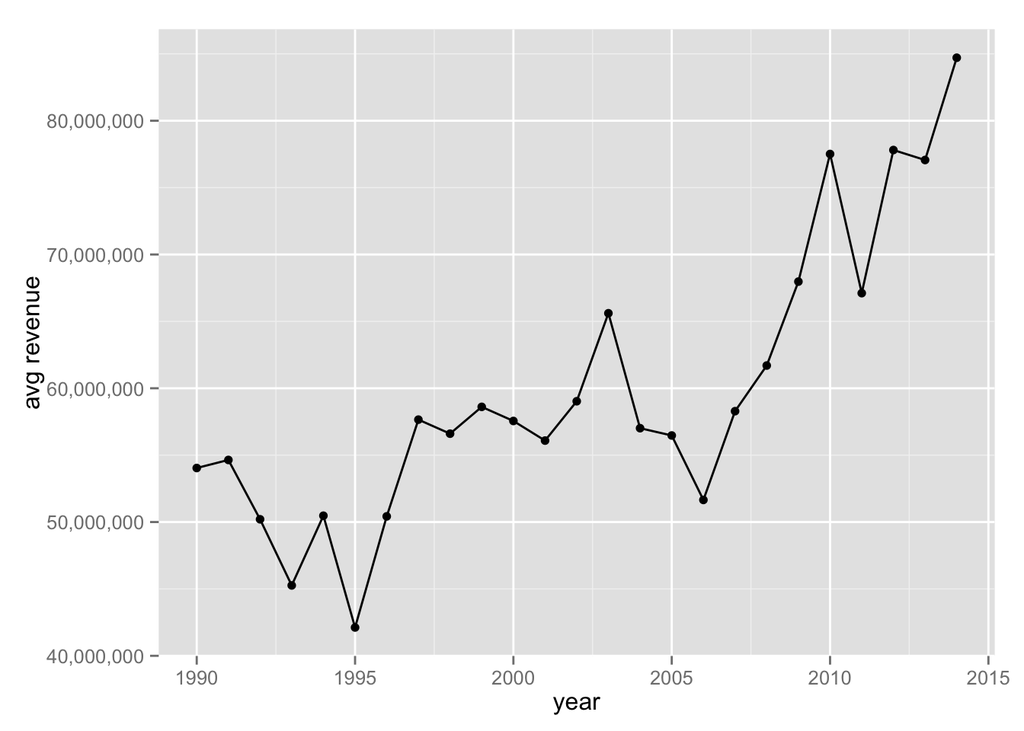

```r
df.by.year %>% filter(year >= 1990) %>%
    ggplot(aes(x = year, y = avg_revenue)) +
    geom_point() +
    geom_line() +
    xlab("year") +
    ylab("avg revenue") +
    scale_y_continuous(labels = comma)
```

**Pro Tip**: `%>%` is SUPER powerful, all it does is make $f(x,y)$ becomes `x %>% f(y)`, so you can use `%>%` on essentially any function, including `ggplot`, `head`, `tail`, `str` and anything that you use frequently in one line without storing intermediate data frames!

Coming back to the analysis, looks like the movie industry is doing very well since 1990s. It increase from 50M in the 1990s to 80M in the 2010s! Up and to the Right!

#### Is there a particular director or movie star that tend to have great hits?

Let us start with directors, since there is only director has only one column, as opposed to 3 actor columns. We all know it’s going to be James Cameron, but let’s double check:

```r
df.by.director = df %>%
        group_by(director) %>%
        summarise(cnt_uu = n_distinct(name),
                  cnt = n(),
                  avg_revenue = mean(revenue)) %>%
        arrange(desc(avg_revenue))

df.by.director %>% head(10) # top 10 money making directors
```

```
## Source: local data frame [10 x 4]
##
##            director cnt_uu cnt avg_revenue
## 1       Joss Whedon      2   3   423766667
## 2       Lee Unkrich      1   1   415000000
## 3       Shane Black      1   1   409000000
## 4      George Lucas      5   5   348400000
## 5        Chris Buck      2   3   324333333
## 6       David Yates      4   4   317500000
## 7     Pierre Coffin      2   2   310000000
## 8  Richard Marquand      1   1   309000000
## 9       Pete Docter      2   2   291500000
## 10   Andrew Adamson      4   4   284500000
```

**Pro Tip**: Urgh!!! when counting distinct, use `n_distinct` intead of `count_distinct`, which was the wrong suggestion in the vignette.

Hmm…, who the heck is Joss Whedon, and what movies did he make?

```r
df.joined %>% filter(director == 'Joss Whedon')
```

```
##           name year  genre runtime rating num_votes  revenue    director
## 1 the avengers 2012 Action     143    8.2    728263 6.23e+08 Joss Whedon
## 2     serenity 2005 Action     119    8.0    210910 2.53e+07 Joss Whedon
## 3 the avengers 1998 Action      89    3.6     32655 6.23e+08 Joss Whedon
##              actor1      actor2             actor3 rated
## 1 Robert Downey Jr. Chris Evans Scarlett Johansson PG_13
## 2    Nathan Fillion Gina Torres   Chiwetel Ejiofor PG_13
## 3 Robert Downey Jr. Chris Evans Scarlett Johansson PG_13
```

and wait, where’s James cameron? let’s search for him:

```r
df.joined %>% filter(director == 'James Cameron')
```

```
##                         name year     genre runtime rating num_votes
## 1                     avatar 2009    Action     162    7.9    714242
## 2                    titanic 1997     Drama     194    7.7    618165
## 3 terminator 2: judgment day 1991    Action     137    8.5    576755
## 4             the terminator 1984    Action     107    8.1    456462
## 5                     aliens 1986    Action     137    8.4    388551
## 6                  true lies 1994    Action     141    7.2    160529
## 7                  the abyss 1989 Adventure     139    7.6    113212
##    revenue      director                actor1                      actor2
## 1 7.61e+08 James Cameron       Sam Worthington                 Zoe Saldana
## 2 6.59e+08 James Cameron     Leonardo DiCaprio                Kate Winslet
## 3 2.05e+08 James Cameron Arnold Schwarzenegger              Linda Hamilton
## 4 3.84e+07 James Cameron Arnold Schwarzenegger              Linda Hamilton
## 5 8.52e+07 James Cameron      Sigourney Weaver               Michael Biehn
## 6 1.46e+08 James Cameron Arnold Schwarzenegger            Jamie Lee Curtis
## 7 5.42e+07 James Cameron             Ed Harris Mary Elizabeth Mastrantonio
##             actor3 rated
## 1 Sigourney Weaver PG_13
## 2       Billy Zane PG_13
## 3   Edward Furlong TV_14
## 4    Michael Biehn     R
## 5      Carrie Henn     R
## 6       Tom Arnold     R
## 7    Michael Biehn PG_13
```

I think I see the problem now, James had made some bad movies in the past (’True lies`?), so taking the average might not be fair. Let’s take max (or median):

```r
df %>%
  group_by(director) %>%
  summarise(cnt_uu = n_distinct(name),
            cnt = n(),
            max_revenue = max(revenue),
            median_revenue = median(revenue)) %>%
  arrange(desc(max_revenue))
```

```
## Source: local data frame [1,273 x 5]
##
##             director cnt_uu cnt max_revenue median_revenue
## 1      James Cameron      7   7    7.61e+08      146000000
## 2        Joss Whedon      2   3    6.23e+08      623000000
## 3  Christopher Nolan      8   8    5.33e+08      136800000
## 4       George Lucas      5   5    4.75e+08      380000000
## 5     Andrew Adamson      4   4    4.36e+08      280000000
## 6   Francis Lawrence      4   4    4.25e+08      165750000
## 7       Roger Allers      2   2    4.23e+08      253650000
## 8        Lee Unkrich      1   1    4.15e+08      415000000
## 9        Shane Black      1   1    4.09e+08      409000000
## 10         Gary Ross      3   3    4.08e+08      120000000
## ..               ...    ... ...         ...            ...
```

Ok, if we look at it by max revenue, James Cameron is still number 1. If we rank by median revenue, the list probably would be different. Be aware of what questions you are trying to ask, and see what statistic is appropriate for your context!

Now, to see which movie star tend to associate with high box office revenue, we will need to do a bit more work. The reason is that our data schema store 3 actors for each movie, so to do what we need, we need to melt the dataset.

```r
library(reshape2)
# dataset pre-melt
df %>% head(3) %>% select(name, actor1, actor2, actor3)
```

```
## Source: local data frame [3 x 4]
##
##                       name            actor1               actor2
## 1 the shawshank redemption       Tim Robbins       Morgan Freeman
## 2          the dark knight    Christian Bale         Heath Ledger
## 3                inception Leonardo DiCaprio Joseph Gordon-Levitt
## Variables not shown: actor3 (fctr)
```

```r
# dataset melted
df %>% head(3) %>%
  select(name, actor1, actor2, actor3, revenue) %>%
  melt(id = c("name", "revenue")) %>%
  select(name, value, revenue)
```

```
##                       name                value  revenue
## 1 the shawshank redemption          Tim Robbins 2.83e+07
## 2          the dark knight       Christian Bale 5.33e+08
## 3                inception    Leonardo DiCaprio 2.93e+08
## 4 the shawshank redemption       Morgan Freeman 2.83e+07
## 5          the dark knight         Heath Ledger 5.33e+08
## 6                inception Joseph Gordon-Levitt 2.93e+08
## 7 the shawshank redemption           Bob Gunton 2.83e+07
## 8          the dark knight        Aaron Eckhart 5.33e+08
## 9                inception           Ellen Page 2.93e+08
```

**Pro Tip**: You can take a look at Hadley’s [documentation](http://had.co.nz/reshape/introduction.pdf) or reference this [quick-R page](http://www.statmethods.net/management/reshape.html).

The above code is just to demonstrate what melt does. It essentially break each record into 3 records, where each actor involved in the same movie has its own row. I think this has to do with the concept of pivot table. Now we are ready to proceed with the analysis:

```r
df.by.actor = df %>%
  select(name, actor1, actor2, actor3, revenue) %>%
  melt(id = c("name", "revenue")) %>%
  select(name, value, revenue)
colnames(df.by.actor) = c("movie", "actor", "revenue")

df.by.actor %>%
  group_by(actor) %>%
  summarise(cnt = n(),
            count_uu = n_distinct(movie),
            avg_revenue = mean(revenue)) %>%
  filter(count_uu > 10) %>%
  arrange(desc(avg_revenue)) %>%
  head(50)
```

```
## Source: local data frame [50 x 4]
##
##                 actor cnt count_uu avg_revenue
## 1        Shia LaBeouf  11       11   165063636
## 2   Robert Downey Jr.  22       21   149317727
## 3         Elijah Wood  11       11   144458182
## 4   Leonardo DiCaprio  18       17   134816667
## 5          Will Smith  21       20   134395714
## 6     Natalie Portman  15       15   132753333
## 7      Bradley Cooper  12       12   131316667
## 8      Christian Bale  16       14   127756250
## 9          Jim Carrey  18       17   118038889
## 10          Tim Allen  13       13   116389231
## 11      Harrison Ford  28       27   115485000
## 12          Tom Hanks  29       28   111134483
```

[output cut: 38 more lines]

*Note: cnt and count_uu should be the same, but I think there is a bug in the IMBD database, we have duplicate movies with wrong year field. Examples: `the avengers` & `the nutty professor`.

```r
df.by.actor %>%
  mutate(global_avg = mean(revenue)) %>%
  group_by(actor) %>%
  summarize(cnt = n(),
            global_avg = first(global_avg),
            avg_revenue = mean(revenue)) %>%
  mutate(inflation_factor = avg_revenue / global_avg) %>%
  arrange(desc(inflation_factor)) %>% head()
```

```
## Source: local data frame [6 x 5]
##
##             actor cnt global_avg avg_revenue inflation_factor
## 1    Kelly Asbury   1   59594245    4.36e+08            7.316
## 2     Rob Minkoff   1   59594245    4.23e+08            7.098
## 3    Idina Menzel   2   59594245    4.01e+08            6.729
## 4    Jennifer Lee   2   59594245    4.01e+08            6.729
## 5 Ellen DeGeneres   1   59594245    3.81e+08            6.393
## 6     Lee Unkrich   1   59594245    3.81e+08            6.393
```

*Note: Again, the intro to plyr vignette is wrong, use `first` instead of `first_value`, `last` instead of `last_value`. Here is an [stack overflow example](http://stackoverflow.com/questions/25184965/r-dplyr-how-to-use-last-first-nth-correct-in-a-sql-database).

**Pro Tip**: Here, we demonstrate how to use `mutate` when we need to add a new column. It’s still kind of stupid that I had to use `first` to extract that value though. Not sure what’s a more efficient way of doing it.

### Some more Advanced Features of dplyr

We have demonstrated the basics of dplyr, and by going through this exercise, hopefully you have developed a good habit of using this new approach to make your code look cleaner, but this is by no means the end. Here are additional resources:

- We didn’t talk about how if you `group by` multiple variables, each `summarise` will unpeel one variable at a time.
- We didn’t talk about windows function or working with databases.
- We didn’t talk about the new stuffs in dplyr 0.2 or 0.3. See [0.2 annoucement](http://blog.rstudio.org/2014/05/21/dplyr-0-2/) and [0.3 annoucement](http://blog.rstudio.org/2014/10/13/dplyr-0-3-2/).
- We didn’t talk about tidyr

#### Here is an example of using tidyr (courtesy of Joshua Lande)

```r
library(dplyr)
library(tidyr)
```

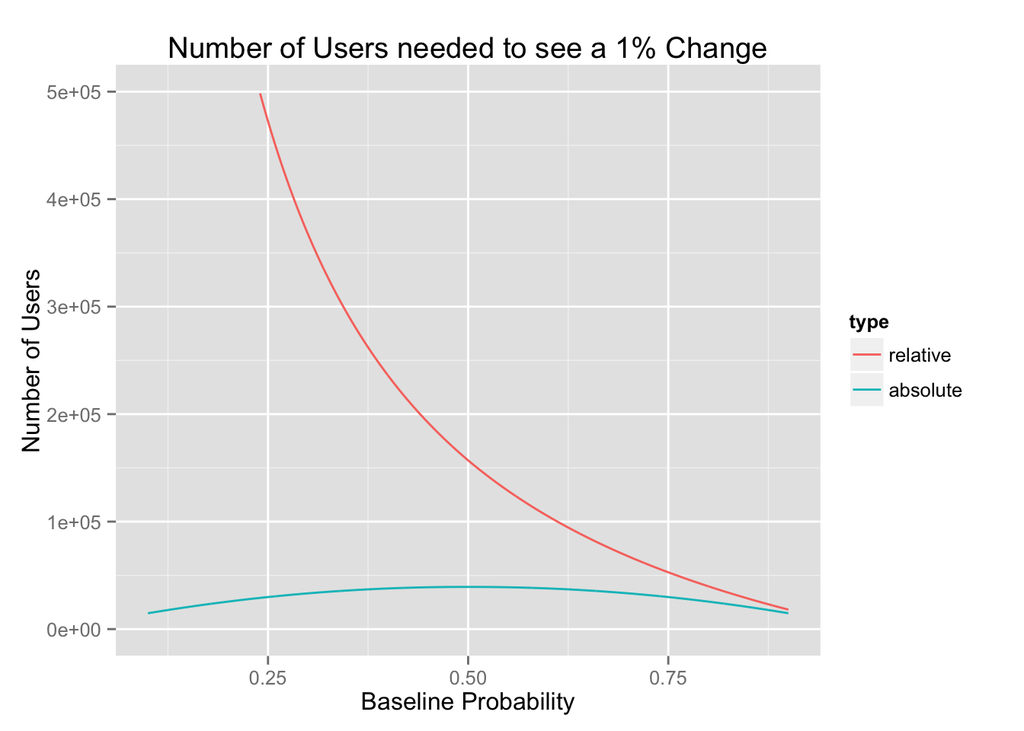

```r
data.frame(p=seq(0.1,0.9,length=1000)) %>%
  rowwise() %>%
  mutate(relative=power.prop.test(p1=p, p2=p*(if (p < 0.5) 1.01 else 0.99),
                                  power=0.8, sig.level=0.05)[[1]],
         absolute=power.prop.test(p1=p, p2=p+(if (p < 0.5) 0.01 else - 0.01),
                                  power=0.8, sig.level=0.05)[[1]]) %>%
  gather(type, n, relative:absolute) %>%
  ggplot(aes(x=p, y=n, color=type)) +
  geom_line() +
  ylim(0,500000) +
  xlab('Baseline Probability') +
  ylab('Number of Users') +
  ggtitle('Number of Users needed to see a 1% Change')
```

The new concept is `rowwise` and `gather`. see rowwise and [intro to tidyr](http://blog.rstudio.org/2014/07/22/introducing-tidyr/).